# Исследование тарифов оператора сотовой связи

## Подготовка данных

### Количество сделанных звонков и израсходованных минут разговора

Добавляю столбец с месяцамив таблицу df_calls.

```python
df_calls['month'] = df_calls['call_date'].astype('datetime64[M]')
df_calls = df_calls.merge(df_users, on='user_id', how = 'left')
df_calls.head()
```

|  | id | call_date | duration | user_id | month | age | churn_date | city | first_name | last_name | reg_date | tariff |
| --- | --- | --- | --- | --- | --- | --- | --- | --- | --- | --- | --- | --- |
| 0 | 1000_0 | 2018-07-25 | 0.0 | 1000 | 2018-07-01 | 52 | NaN | Краснодар | Рафаил | Верещагин | 2018-05-25 | ultra |
| 1 | 1000_1 | 2018-08-17 | 0.0 | 1000 | 2018-08-01 | 52 | NaN | Краснодар | Рафаил | Верещагин | 2018-05-25 | ultra |
| 2 | 1000_2 | 2018-06-11 | 3.0 | 1000 | 2018-06-01 | 52 | NaN | Краснодар | Рафаил | Верещагин | 2018-05-25 | ultra |
| 3 | 1000_3 | 2018-09-21 | 14.0 | 1000 | 2018-09-01 | 52 | NaN | Краснодар | Рафаил | Верещагин | 2018-05-25 | ultra |
| 4 | 1000_4 | 2018-12-15 | 6.0 | 1000 | 2018-12-01 | 52 | NaN | Краснодар | Рафаил | Верещагин | 2018-05-25 | ultra |

Ищу количество сделанных звонков и израсходованных минут разговора по месяцам для каждого пользователя.

```python
calls_group = df_calls.groupby(['user_id', 'month']).agg({'id':'count','duration':'sum'})
calls_group.columns = ['calls_count', 'calls_duration']
calls_group.head()
```

| user_id | month | calls_count | calls_duration |
| --- | --- | --- | --- |
| 1000 | 2018-05-01 | 22 | 159.0 |
|  | 2018-06-01 | 43 | 172.0 |
|  | 2018-07-01 | 47 | 340.0 |
|  | 2018-08-01 | 52 | 408.0 |
|  | 2018-09-01 | 58 | 466.0 |

### Количество отправленных сообщений по месяцам

```python
df_messages['month'] = df_calls['call_date'].astype('datetime64[M]')
df_messages.head()
```

|  | id | message_date | user_id | month |
| --- | --- | --- | --- | --- |
| 0 | 1000_0 | 2018-06-27 | 1000 | 2018-07-01 |
| 1 | 1000_1 | 2018-10-08 | 1000 | 2018-08-01 |
| 2 | 1000_2 | 2018-08-04 | 1000 | 2018-06-01 |
| 3 | 1000_3 | 2018-06-16 | 1000 | 2018-09-01 |
| 4 | 1000_4 | 2018-12-05 | 1000 | 2018-12-01 |

Ищу количество отправленных сообщений по месяцам для каждого пользователя.

```python
messages_group = df_messages.groupby(['user_id', 'month'])['id'].count()
messages_group
```

```
user_id  month
1000     2018-05-01    22
         2018-06-01    43
         2018-07-01    47
         2018-08-01    53
         2018-09-01    59
                       ..
1499     2018-08-01    24
         2018-09-01    20
         2018-10-01    35
         2018-11-01    37
         2018-12-01    29
Name: id, Length: 3741, dtype: int64
```

### Объем израсходованного интернет-трафика по месяцам

Добавляю в таблицу столбец с месяцами в таблицу df_internet.

```python
df_internet.head()
```

|  | Unnamed: 0 | id | mb_used | session_date | user_id |
| --- | --- | --- | --- | --- | --- |
| 0 | 0 | 1000_0 | 112.95 | 2018-11-25 | 1000 |
| 1 | 1 | 1000_1 | 1052.81 | 2018-09-07 | 1000 |
| 2 | 2 | 1000_2 | 1197.26 | 2018-06-25 | 1000 |
| 3 | 3 | 1000_3 | 550.27 | 2018-08-22 | 1000 |
| 4 | 4 | 1000_4 | 302.56 | 2018-09-24 | 1000 |

```python
df_internet['month'] = df_internet['session_date'].astype('datetime64[M]')
df_internet.head()
```

|  | Unnamed: 0 | id | mb_used | session_date | user_id | month |
| --- | --- | --- | --- | --- | --- | --- |
| 0 | 0 | 1000_0 | 112.95 | 2018-11-25 | 1000 | 2018-11-01 |
| 1 | 1 | 1000_1 | 1052.81 | 2018-09-07 | 1000 | 2018-09-01 |
| 2 | 2 | 1000_2 | 1197.26 | 2018-06-25 | 1000 | 2018-06-01 |
| 3 | 3 | 1000_3 | 550.27 | 2018-08-22 | 1000 | 2018-08-01 |
| 4 | 4 | 1000_4 | 302.56 | 2018-09-24 | 1000 | 2018-09-01 |

Ищу объем интернет трафика по месяцам для каждого пользователя.

```python
internet_group = df_internet.groupby(['user_id', 'month'])['mb_used'].sum()
internet_group
```

```
user_id  month
1000     2018-05-01     2253.49
         2018-06-01    23233.77
         2018-07-01    14003.64
         2018-08-01    14055.93
         2018-09-01    14568.91
                         ...
1498     2018-10-01    20579.36
1499     2018-09-01     1845.75
         2018-10-01    17788.51
         2018-11-01    17963.31
         2018-12-01    13055.58
Name: mb_used, Length: 3203, dtype: float64
```

### Объединение таблиц

```python
df = calls_group.merge(messages_group, on= ['user_id','month'], how='outer')
df = df.merge(internet_group,on= ['user_id','month'], how='outer')
df.columns = ['calls_count','calls_duration','messages','mb_used']
df.head()
```

| user_id | month | calls_count | calls_duration | messages | mb_used |
| --- | --- | --- | --- | --- | --- |
| 1000 | 2018-05-01 | 22.0 | 159.0 | 22.0 | 2253.49 |
|  | 2018-06-01 | 43.0 | 172.0 | 43.0 | 23233.77 |
|  | 2018-07-01 | 47.0 | 340.0 | 47.0 | 14003.64 |
|  | 2018-08-01 | 52.0 | 408.0 | 53.0 | 14055.93 |
|  | 2018-09-01 | 58.0 | 466.0 | 59.0 | 14568.91 |

Добавляю в таблицу данные о пользователях. Для этого убираю индексы.

```python
df = df.reset_index()
df
```

|  | user_id | month | calls_count | calls_duration | messages | mb_used |
| --- | --- | --- | --- | --- | --- | --- |
| 0 | 1000 | 2018-05-01 | 22.0 | 159.0 | 22.0 | 2253.49 |
| 1 | 1000 | 2018-06-01 | 43.0 | 172.0 | 43.0 | 23233.77 |
| 2 | 1000 | 2018-07-01 | 47.0 | 340.0 | 47.0 | 14003.64 |
| 3 | 1000 | 2018-08-01 | 52.0 | 408.0 | 53.0 | 14055.93 |
| 4 | 1000 | 2018-09-01 | 58.0 | 466.0 | 59.0 | 14568.91 |
| ... | ... | ... | ... | ... | ... | ... |
| 4531 | 1499 | 2018-05-01 | NaN | NaN | 6.0 | NaN |
| 4532 | 1499 | 2018-06-01 | NaN | NaN | 5.0 | NaN |
| 4533 | 1499 | 2018-07-01 | NaN | NaN | 25.0 | NaN |
| 4534 | 1499 | 2018-08-01 | NaN | NaN | 24.0 | NaN |
| 4535 | 1476 | 2018-04-01 | NaN | NaN | NaN | 530.78 |

4536 rows × 6 columns

```python
df = df.merge(df_users, on='user_id', how='left', suffixes=('_df','_users'))
df.head(20)
```

|  | user_id | month | calls_count | calls_duration | messages | mb_used | age | churn_date | city | first_name | last_name | reg_date | tariff |
| --- | --- | --- | --- | --- | --- | --- | --- | --- | --- | --- | --- | --- | --- |
| 0 | 1000 | 2018-05-01 | 22.0 | 159.0 | 22.0 | 2253.49 | 52 | NaN | Краснодар | Рафаил | Верещагин | 2018-05-25 | ultra |
| 1 | 1000 | 2018-06-01 | 43.0 | 172.0 | 43.0 | 23233.77 | 52 | NaN | Краснодар | Рафаил | Верещагин | 2018-05-25 | ultra |
| 2 | 1000 | 2018-07-01 | 47.0 | 340.0 | 47.0 | 14003.64 | 52 | NaN | Краснодар | Рафаил | Верещагин | 2018-05-25 | ultra |
| 3 | 1000 | 2018-08-01 | 52.0 | 408.0 | 53.0 | 14055.93 | 52 | NaN | Краснодар | Рафаил | Верещагин | 2018-05-25 | ultra |
| 4 | 1000 | 2018-09-01 | 58.0 | 466.0 | 59.0 | 14568.91 | 52 | NaN | Краснодар | Рафаил | Верещагин | 2018-05-25 | ultra |
| 5 | 1000 | 2018-10-01 | 57.0 | 350.0 | 57.0 | 14702.49 | 52 | NaN | Краснодар | Рафаил | Верещагин | 2018-05-25 | ultra |
| 6 | 1000 | 2018-11-01 | 43.0 | 338.0 | 103.0 | 14756.47 | 52 | NaN | Краснодар | Рафаил | Верещагин | 2018-05-25 | ultra |
| 7 | 1000 | 2018-12-01 | 46.0 | 333.0 | 112.0 | 9817.61 | 52 | NaN | Краснодар | Рафаил | Верещагин | 2018-05-25 | ultra |
| 8 | 1001 | 2018-11-01 | 59.0 | 430.0 | NaN | 18429.34 | 41 | NaN | Москва | Иван | Ежов | 2018-11-01 | smart |
| 9 | 1001 | 2018-12-01 | 63.0 | 414.0 | NaN | 14036.66 | 41 | NaN | Москва | Иван | Ежов | 2018-11-01 | smart |
| 10 | 1002 | 2018-06-01 | 15.0 | 117.0 | 7.0 | 10856.82 | 59 | NaN | Стерлитамак | Евгений | Абрамович | 2018-06-17 | smart |
| 11 | 1002 | 2018-07-01 | 26.0 | 214.0 | 8.0 | 17580.10 | 59 | NaN | Стерлитамак | Евгений | Абрамович | 2018-06-17 | smart |
| 12 | 1002 | 2018-08-01 | 42.0 | 289.0 | 13.0 | 20319.26 | 59 | NaN | Стерлитамак | Евгений | Абрамович | 2018-06-17 | smart |
| 13 | 1002 | 2018-09-01 | 36.0 | 206.0 | 10.0 | 16691.08 | 59 | NaN | Стерлитамак | Евгений | Абрамович | 2018-06-17 | smart |
| 14 | 1002 | 2018-10-01 | 33.0 | 212.0 | 9.0 | 13888.25 | 59 | NaN | Стерлитамак | Евгений | Абрамович | 2018-06-17 | smart |
| 15 | 1002 | 2018-11-01 | 32.0 | 243.0 | 15.0 | 18587.28 | 59 | NaN | Стерлитамак | Евгений | Абрамович | 2018-06-17 | smart |
| 16 | 1002 | 2018-12-01 | 33.0 | 236.0 | 8.0 | 18113.73 | 59 | NaN | Стерлитамак | Евгений | Абрамович | 2018-06-17 | smart |
| 17 | 1003 | 2018-08-01 | 55.0 | 380.0 | 55.0 | 8565.21 | 23 | NaN | Москва | Белла | Белякова | 2018-08-17 | ultra |
| 18 | 1003 | 2018-09-01 | 134.0 | 961.0 | 81.0 | 12468.87 | 23 | NaN | Москва | Белла | Белякова | 2018-08-17 | ultra |
| 19 | 1003 | 2018-10-01 | 108.0 | 855.0 | 77.0 | 14768.14 | 23 | NaN | Москва | Белла | Белякова | 2018-08-17 | ultra |

### Расчет помесячной выручки с каждого пользователя

Еще раз вызываю информацию о тарифах, добавляю данные в общую таблицу.

```python
df_tariffs
```

|  | messages_included | mb_per_month_included | minutes_included | rub_monthly_fee | rub_per_gb | rub_per_message | rub_per_minute | tariff_name |
| --- | --- | --- | --- | --- | --- | --- | --- | --- |
| 0 | 50 | 15360 | 500 | 550 | 200 | 3 | 3 | smart |
| 1 | 1000 | 30720 | 3000 | 1950 | 150 | 1 | 1 | ultra |

```python
df = df.merge(df_tariffs, left_on='tariff', right_on='tariff_name', how='left')
df
```

|  | user_id | month | calls_count | calls_duration | messages | mb_used | age | churn_date | city | first_name | ... | reg_date | tariff | messages_included | mb_per_month_included | minutes_included | rub_monthly_fee | rub_per_gb | rub_per_message | rub_per_minute | tariff_name |
| --- | --- | --- | --- | --- | --- | --- | --- | --- | --- | --- | --- | --- | --- | --- | --- | --- | --- | --- | --- | --- | --- |
| 0 | 1000 | 2018-05-01 | 22.0 | 159.0 | 22.0 | 2253.49 | 52 | NaN | Краснодар | Рафаил | ... | 2018-05-25 | ultra | 1000 | 30720 | 3000 | 1950 | 150 | 1 | 1 | ultra |
| 1 | 1000 | 2018-06-01 | 43.0 | 172.0 | 43.0 | 23233.77 | 52 | NaN | Краснодар | Рафаил | ... | 2018-05-25 | ultra | 1000 | 30720 | 3000 | 1950 | 150 | 1 | 1 | ultra |
| 2 | 1000 | 2018-07-01 | 47.0 | 340.0 | 47.0 | 14003.64 | 52 | NaN | Краснодар | Рафаил | ... | 2018-05-25 | ultra | 1000 | 30720 | 3000 | 1950 | 150 | 1 | 1 | ultra |
| 3 | 1000 | 2018-08-01 | 52.0 | 408.0 | 53.0 | 14055.93 | 52 | NaN | Краснодар | Рафаил | ... | 2018-05-25 | ultra | 1000 | 30720 | 3000 | 1950 | 150 | 1 | 1 | ultra |
| 4 | 1000 | 2018-09-01 | 58.0 | 466.0 | 59.0 | 14568.91 | 52 | NaN | Краснодар | Рафаил | ... | 2018-05-25 | ultra | 1000 | 30720 | 3000 | 1950 | 150 | 1 | 1 | ultra |
| ... | ... | ... | ... | ... | ... | ... | ... | ... | ... | ... | ... | ... | ... | ... | ... | ... | ... | ... | ... | ... | ... |
| 4531 | 1499 | 2018-05-01 | NaN | NaN | 6.0 | NaN | 35 | NaN | Пермь | Гектор | ... | 2018-09-27 | smart | 50 | 15360 | 500 | 550 | 200 | 3 | 3 | smart |
| 4532 | 1499 | 2018-06-01 | NaN | NaN | 5.0 | NaN | 35 | NaN | Пермь | Гектор | ... | 2018-09-27 | smart | 50 | 15360 | 500 | 550 | 200 | 3 | 3 | smart |
| 4533 | 1499 | 2018-07-01 | NaN | NaN | 25.0 | NaN | 35 | NaN | Пермь | Гектор | ... | 2018-09-27 | smart | 50 | 15360 | 500 | 550 | 200 | 3 | 3 | smart |
| 4534 | 1499 | 2018-08-01 | NaN | NaN | 24.0 | NaN | 35 | NaN | Пермь | Гектор | ... | 2018-09-27 | smart | 50 | 15360 | 500 | 550 | 200 | 3 | 3 | smart |
| 4535 | 1476 | 2018-04-01 | NaN | NaN | NaN | 530.78 | 50 | NaN | Москва | Валентина | ... | 2018-04-30 | ultra | 1000 | 30720 | 3000 | 1950 | 150 | 1 | 1 | ultra |

4536 rows × 21 columns

### Работа с пропущенными значениями

Проверяю полученную таблицу на пропущенные значения.

```python
df.isna().sum()
```

```
user_id                     0
month                       0
calls_count              1362
calls_duration           1362
messages                  795
mb_used                  1333
age                         0
churn_date               4248
city                        0
first_name                  0
last_name                   0
reg_date                    0
tariff                      0
messages_included           0
mb_per_month_included       0
minutes_included            0
rub_monthly_fee             0
rub_per_gb                  0
rub_per_message             0
rub_per_minute              0
tariff_name                 0
dtype: int64
```

Для столбцов calls_count, calls_duration, messages, mb_used пропущенные значения меняю на ноль, так как это означает, что пользователь не использовал в какой-то месяц звонки, сообщения или интернет.

```python
df['calls_count'] = df['calls_count'].fillna(0)
df['calls_duration'] = df['calls_duration'].fillna(0)
df['messages'] = df['messages'].fillna(0)
df['mb_used'] = df['mb_used'].fillna(0)
df.isna().sum()
```

```
user_id                     0
month                       0
calls_count                 0
calls_duration              0
messages                    0
mb_used                     0
age                         0
churn_date               4248
city                        0
first_name                  0
last_name                   0
reg_date                    0
tariff                      0
messages_included           0
mb_per_month_included       0
minutes_included            0
rub_monthly_fee             0
rub_per_gb                  0
rub_per_message             0
rub_per_minute              0
tariff_name                 0
dtype: int64
```

### Перерасход минут

Вычитаю бесплатный лимит из суммарного количества звонков. Пишу функцию, которая будет возвращать перерасход минут или ноль, если перерасхода не было.

```python
def minutes_count(row):
    minutes = row['calls_duration'] - row['minutes_included']
    if minutes >0:
        return minutes
    if minutes<= 0:
        return 0
    return 0
```

```python
df['extra_minutes'] = df.apply(minutes_count, axis=1).astype('int')
df.query('extra_minutes>0').head()
```

|  | user_id | month | calls_count | calls_duration | messages | mb_used | age | churn_date | city | first_name | ... | tariff | messages_included | mb_per_month_included | minutes_included | rub_monthly_fee | rub_per_gb | rub_per_message | rub_per_minute | tariff_name | extra_minutes |
| --- | --- | --- | --- | --- | --- | --- | --- | --- | --- | --- | --- | --- | --- | --- | --- | --- | --- | --- | --- | --- | --- |
| 32 | 1005 | 2018-03-01 | 77.0 | 606.0 | 51.0 | 11104.25 | 67 | NaN | Набережные Челны | Афанасий | ... | smart | 50 | 15360 | 500 | 550 | 200 | 3 | 3 | smart | 106 |
| 33 | 1005 | 2018-04-01 | 101.0 | 712.0 | 59.0 | 9351.72 | 67 | NaN | Набережные Челны | Афанасий | ... | smart | 50 | 15360 | 500 | 550 | 200 | 3 | 3 | smart | 212 |
| 34 | 1005 | 2018-05-01 | 73.0 | 595.0 | 59.0 | 7865.53 | 67 | NaN | Набережные Челны | Афанасий | ... | smart | 50 | 15360 | 500 | 550 | 200 | 3 | 3 | smart | 95 |
| 35 | 1005 | 2018-06-01 | 80.0 | 612.0 | 50.0 | 9863.19 | 67 | NaN | Набережные Челны | Афанасий | ... | smart | 50 | 15360 | 500 | 550 | 200 | 3 | 3 | smart | 112 |
| 36 | 1005 | 2018-07-01 | 77.0 | 569.0 | 46.0 | 7694.56 | 67 | NaN | Набережные Челны | Афанасий | ... | smart | 50 | 15360 | 500 | 550 | 200 | 3 | 3 | smart | 69 |

5 rows × 22 columns

### Перерасход сообщений

Вычитаю бесплатный лимит из суммарного количества сообщений за месяц. Пишу функцию, которая будет возвращать перерасход сообщений или ноль, если перерасхода не было.

```python
def messages_count(row):
    messages = row['messages'] - row['messages_included']
    if messages >0:
        return messages
    if messages<= 0:
        return 0
    return 0
```

```python
df['extra_messages'] = df.apply(messages_count, axis=1).astype('int')
pd.set_option('display.max_columns', None)
df.query('extra_messages>0').head()
```

|  | user_id | month | calls_count | calls_duration | messages | mb_used | age | churn_date | city | first_name | last_name | reg_date | tariff | messages_included | mb_per_month_included | minutes_included | rub_monthly_fee | rub_per_gb | rub_per_message | rub_per_minute | tariff_name | extra_minutes | extra_messages |
| --- | --- | --- | --- | --- | --- | --- | --- | --- | --- | --- | --- | --- | --- | --- | --- | --- | --- | --- | --- | --- | --- | --- | --- |
| 32 | 1005 | 2018-03-01 | 77.0 | 606.0 | 51.0 | 11104.25 | 67 | NaN | Набережные Челны | Афанасий | Горлов | 2018-01-25 | smart | 50 | 15360 | 500 | 550 | 200 | 3 | 3 | smart | 106 | 1 |
| 33 | 1005 | 2018-04-01 | 101.0 | 712.0 | 59.0 | 9351.72 | 67 | NaN | Набережные Челны | Афанасий | Горлов | 2018-01-25 | smart | 50 | 15360 | 500 | 550 | 200 | 3 | 3 | smart | 212 | 9 |
| 34 | 1005 | 2018-05-01 | 73.0 | 595.0 | 59.0 | 7865.53 | 67 | NaN | Набережные Челны | Афанасий | Горлов | 2018-01-25 | smart | 50 | 15360 | 500 | 550 | 200 | 3 | 3 | smart | 95 | 9 |
| 38 | 1005 | 2018-09-01 | 66.0 | 479.0 | 61.0 | 7016.46 | 67 | NaN | Набережные Челны | Афанасий | Горлов | 2018-01-25 | smart | 50 | 15360 | 500 | 550 | 200 | 3 | 3 | smart | 0 | 11 |
| 39 | 1005 | 2018-10-01 | 100.0 | 723.0 | 57.0 | 7800.93 | 67 | NaN | Набережные Челны | Афанасий | Горлов | 2018-01-25 | smart | 50 | 15360 | 500 | 550 | 200 | 3 | 3 | smart | 223 | 7 |

### Перерасход интернет-трафика

Пишу еще одну функцию, которая посчитает перерасход интернет-трафика.

```python
def traffic_count(row):
    traffic = row['mb_used'] - row['mb_per_month_included']
    if traffic >0:
        return traffic/1024
    if traffic<= 0:
        return 0
    return 0
```

```python
df['extra_traffic'] = df.apply(traffic_count, axis=1)
df.query('extra_traffic>0').head()
```

|  | user_id | month | calls_count | calls_duration | messages | mb_used | age | churn_date | city | first_name | last_name | reg_date | tariff | messages_included | mb_per_month_included | minutes_included | rub_monthly_fee | rub_per_gb | rub_per_message | rub_per_minute | tariff_name | extra_minutes | extra_messages | extra_traffic |
| --- | --- | --- | --- | --- | --- | --- | --- | --- | --- | --- | --- | --- | --- | --- | --- | --- | --- | --- | --- | --- | --- | --- | --- | --- |
| 8 | 1001 | 2018-11-01 | 59.0 | 430.0 | 0.0 | 18429.34 | 41 | NaN | Москва | Иван | Ежов | 2018-11-01 | smart | 50 | 15360 | 500 | 550 | 200 | 3 | 3 | smart | 0 | 0 | 2.997402 |
| 11 | 1002 | 2018-07-01 | 26.0 | 214.0 | 8.0 | 17580.10 | 59 | NaN | Стерлитамак | Евгений | Абрамович | 2018-06-17 | smart | 50 | 15360 | 500 | 550 | 200 | 3 | 3 | smart | 0 | 0 | 2.168066 |
| 12 | 1002 | 2018-08-01 | 42.0 | 289.0 | 13.0 | 20319.26 | 59 | NaN | Стерлитамак | Евгений | Абрамович | 2018-06-17 | smart | 50 | 15360 | 500 | 550 | 200 | 3 | 3 | smart | 0 | 0 | 4.843027 |
| 13 | 1002 | 2018-09-01 | 36.0 | 206.0 | 10.0 | 16691.08 | 59 | NaN | Стерлитамак | Евгений | Абрамович | 2018-06-17 | smart | 50 | 15360 | 500 | 550 | 200 | 3 | 3 | smart | 0 | 0 | 1.299883 |
| 15 | 1002 | 2018-11-01 | 32.0 | 243.0 | 15.0 | 18587.28 | 59 | NaN | Стерлитамак | Евгений | Абрамович | 2018-06-17 | smart | 50 | 15360 | 500 | 550 | 200 | 3 | 3 | smart | 0 | 0 | 3.151641 |

Округляю перерасход трафика в большую сторону.

```python
df['extra_traffic'] = np.ceil(df['extra_traffic'])
df.query('extra_traffic>0').head()
```

|  | user_id | month | calls_count | calls_duration | messages | mb_used | age | churn_date | city | first_name | last_name | reg_date | tariff | messages_included | mb_per_month_included | minutes_included | rub_monthly_fee | rub_per_gb | rub_per_message | rub_per_minute | tariff_name | extra_minutes | extra_messages | extra_traffic |
| --- | --- | --- | --- | --- | --- | --- | --- | --- | --- | --- | --- | --- | --- | --- | --- | --- | --- | --- | --- | --- | --- | --- | --- | --- |
| 8 | 1001 | 2018-11-01 | 59.0 | 430.0 | 0.0 | 18429.34 | 41 | NaN | Москва | Иван | Ежов | 2018-11-01 | smart | 50 | 15360 | 500 | 550 | 200 | 3 | 3 | smart | 0 | 0 | 3.0 |
| 11 | 1002 | 2018-07-01 | 26.0 | 214.0 | 8.0 | 17580.10 | 59 | NaN | Стерлитамак | Евгений | Абрамович | 2018-06-17 | smart | 50 | 15360 | 500 | 550 | 200 | 3 | 3 | smart | 0 | 0 | 3.0 |
| 12 | 1002 | 2018-08-01 | 42.0 | 289.0 | 13.0 | 20319.26 | 59 | NaN | Стерлитамак | Евгений | Абрамович | 2018-06-17 | smart | 50 | 15360 | 500 | 550 | 200 | 3 | 3 | smart | 0 | 0 | 5.0 |
| 13 | 1002 | 2018-09-01 | 36.0 | 206.0 | 10.0 | 16691.08 | 59 | NaN | Стерлитамак | Евгений | Абрамович | 2018-06-17 | smart | 50 | 15360 | 500 | 550 | 200 | 3 | 3 | smart | 0 | 0 | 2.0 |
| 15 | 1002 | 2018-11-01 | 32.0 | 243.0 | 15.0 | 18587.28 | 59 | NaN | Стерлитамак | Евгений | Абрамович | 2018-06-17 | smart | 50 | 15360 | 500 | 550 | 200 | 3 | 3 | smart | 0 | 0 | 4.0 |

Рассчитываю, какую сумму нужно доплатить абоненту за месяц, умножая перасход по сообщениям, минутам звонков и гигабайтам на стоимость из тарифного плана и прибавляю абонентскую плату.

```python
df['total_cost'] = (df['extra_minutes']*df['rub_per_minute']
                    + df['extra_messages']*df['rub_per_message']
                    + df['extra_traffic']*df['rub_per_gb']
                   + df['rub_monthly_fee'])
df.query('total_cost>rub_monthly_fee').head()
```

|  | user_id | month | calls_count | calls_duration | messages | mb_used | age | churn_date | city | first_name | last_name | reg_date | tariff | messages_included | mb_per_month_included | minutes_included | rub_monthly_fee | rub_per_gb | rub_per_message | rub_per_minute | tariff_name | extra_minutes | extra_messages | extra_traffic | total_cost |
| --- | --- | --- | --- | --- | --- | --- | --- | --- | --- | --- | --- | --- | --- | --- | --- | --- | --- | --- | --- | --- | --- | --- | --- | --- | --- |
| 8 | 1001 | 2018-11-01 | 59.0 | 430.0 | 0.0 | 18429.34 | 41 | NaN | Москва | Иван | Ежов | 2018-11-01 | smart | 50 | 15360 | 500 | 550 | 200 | 3 | 3 | smart | 0 | 0 | 3.0 | 1150.0 |
| 11 | 1002 | 2018-07-01 | 26.0 | 214.0 | 8.0 | 17580.10 | 59 | NaN | Стерлитамак | Евгений | Абрамович | 2018-06-17 | smart | 50 | 15360 | 500 | 550 | 200 | 3 | 3 | smart | 0 | 0 | 3.0 | 1150.0 |
| 12 | 1002 | 2018-08-01 | 42.0 | 289.0 | 13.0 | 20319.26 | 59 | NaN | Стерлитамак | Евгений | Абрамович | 2018-06-17 | smart | 50 | 15360 | 500 | 550 | 200 | 3 | 3 | smart | 0 | 0 | 5.0 | 1550.0 |
| 13 | 1002 | 2018-09-01 | 36.0 | 206.0 | 10.0 | 16691.08 | 59 | NaN | Стерлитамак | Евгений | Абрамович | 2018-06-17 | smart | 50 | 15360 | 500 | 550 | 200 | 3 | 3 | smart | 0 | 0 | 2.0 | 950.0 |
| 15 | 1002 | 2018-11-01 | 32.0 | 243.0 | 15.0 | 18587.28 | 59 | NaN | Стерлитамак | Евгений | Абрамович | 2018-06-17 | smart | 50 | 15360 | 500 | 550 | 200 | 3 | 3 | smart | 0 | 0 | 4.0 | 1350.0 |

Перевожу в тип integer значения в столбцах calls_count и calls_duration и messages.

```python
df = df.astype({'calls_count':'int', 'calls_duration': 'int', 'messages':'int'})
```

```python
a = df.query('total_cost>rub_monthly_fee')['total_cost'].count()/df.shape[0]
b = df.query('total_cost>rub_monthly_fee and tariff_name == "smart"')['total_cost'].count()/df.shape[0]
c = df.query('total_cost>rub_monthly_fee and tariff_name == "ultra"')['total_cost'].count()/df.shape[0]
print(f'Перерасход средств относительно всех данных по месяцам {a:.0%}')
print(f'Перерасход средств по тарифу Smart от всех данных по месяцам {b:.0%}')
print(f'Перерасход средств по тарифу Ultra от всех данных по месяцам {c:.0%}')
```

```
Перерасход средств относительно всех данных по месяцам 40%
Перерасход средств по тарифу Smart от всех данных по месяцам 37%
Перерасход средств по тарифу Ultra от всех данных по месяцам 3%
```

### Вывод

Перехожу к анализу данных.

## Анализ данных

**Задача**: Опишите поведение клиентов оператора, исходя из выборки.

- Сколько минут разговора, сколько сообщений и какой объём интернет-трафика требуется пользователям каждого тарифа в месяц?
- Посчитайте среднее количество, дисперсию и стандартное отклонение.
- Постройте гистограммы.
- Опишите распределения.

Ишу, скольо минут разговора, сколько сообщений и какой объём интернет-трафика требуется пользователям каждого тарифа в месяц.

```python
df.head()
```

|  | user_id | month | calls_count | calls_duration | messages | mb_used | age | churn_date | city | first_name | last_name | reg_date | tariff | messages_included | mb_per_month_included | minutes_included | rub_monthly_fee | rub_per_gb | rub_per_message | rub_per_minute | tariff_name | extra_minutes | extra_messages | extra_traffic | total_cost |
| --- | --- | --- | --- | --- | --- | --- | --- | --- | --- | --- | --- | --- | --- | --- | --- | --- | --- | --- | --- | --- | --- | --- | --- | --- | --- |
| 0 | 1000 | 2018-05-01 | 22 | 159 | 22 | 2253.49 | 52 | NaN | Краснодар | Рафаил | Верещагин | 2018-05-25 | ultra | 1000 | 30720 | 3000 | 1950 | 150 | 1 | 1 | ultra | 0 | 0 | 0.0 | 1950.0 |
| 1 | 1000 | 2018-06-01 | 43 | 172 | 43 | 23233.77 | 52 | NaN | Краснодар | Рафаил | Верещагин | 2018-05-25 | ultra | 1000 | 30720 | 3000 | 1950 | 150 | 1 | 1 | ultra | 0 | 0 | 0.0 | 1950.0 |
| 2 | 1000 | 2018-07-01 | 47 | 340 | 47 | 14003.64 | 52 | NaN | Краснодар | Рафаил | Верещагин | 2018-05-25 | ultra | 1000 | 30720 | 3000 | 1950 | 150 | 1 | 1 | ultra | 0 | 0 | 0.0 | 1950.0 |
| 3 | 1000 | 2018-08-01 | 52 | 408 | 53 | 14055.93 | 52 | NaN | Краснодар | Рафаил | Верещагин | 2018-05-25 | ultra | 1000 | 30720 | 3000 | 1950 | 150 | 1 | 1 | ultra | 0 | 0 | 0.0 | 1950.0 |
| 4 | 1000 | 2018-09-01 | 58 | 466 | 59 | 14568.91 | 52 | NaN | Краснодар | Рафаил | Верещагин | 2018-05-25 | ultra | 1000 | 30720 | 3000 | 1950 | 150 | 1 | 1 | ultra | 0 | 0 | 0.0 | 1950.0 |

```python
df_tariffs
```

|  | messages_included | mb_per_month_included | minutes_included | rub_monthly_fee | rub_per_gb | rub_per_message | rub_per_minute | tariff_name |
| --- | --- | --- | --- | --- | --- | --- | --- | --- |
| 0 | 50 | 15360 | 500 | 550 | 200 | 3 | 3 | smart |
| 1 | 1000 | 30720 | 3000 | 1950 | 150 | 1 | 1 | ultra |

### Потребность в минутах звонков в месяц

Смотрю среднее, медиану и стандартное отклонение по тарифу Ultra методом describe.

```python
df.query('tariff_name=="ultra"')['calls_duration'].describe()
```

```
count    1381.000000
mean      375.614772
std       358.733106
min         0.000000
25%         0.000000
50%       332.000000
75%       643.000000
max      1673.000000
Name: calls_duration, dtype: float64
```

25% от данных содержат нули, это значит, что пользователи никуда не звонили в этот месяц или звонили и сбрасывали, или был сбой звонка. Меня интересуют те, кто разговаривал, поэтому я убираю из выборки все значения, равные нулю, предварительно посчитав, сколько таких значений.

```python
print(df.query('tariff_name=="ultra" and calls_duration == 0')['calls_duration'].count(), 'строки с нулями в тарифе Ultra')
ultra = df.query('tariff_name=="ultra"')['user_id'].count()
print(ultra, 'строк с тарифом Ultra')
print(f'{434/1381:.0%} строк не содержат ни одной минуты звонка для тарифа Ultra')
```

```
434 строки с нулями в тарифе Ultra
1381 строк с тарифом Ultra
31% строк не содержат ни одной минуты звонка для тарифа Ultra
```

```python
norm_calls_ultra = df.query('tariff_name=="ultra" and calls_duration > 0') # убираю нулевую продолжительность звонка
```

Еще раз смотрю среднее, медиану и стандартное отклонение по тарифу Ultra.

```python
norm_calls_ultra['calls_duration'].describe()
```

```
count     947.000000
mean      547.755016
std       305.513385
min         1.000000
25%       311.000000
50%       529.000000
75%       758.000000
max      1673.000000
Name: calls_duration, dtype: float64
```

Стандартное отклонение уменьшилось с 359 до 306, среднее и медиана выросли. строю диаграмму размаха, чтобы проверить наличие аномальных значений и их количество.

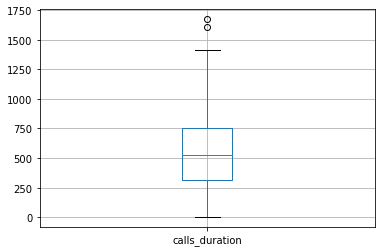

```python
norm_calls_ultra.boxplot('calls_duration');
```

В выборке присутствуют единичные аномальные значения, оставлю их.

Для тарифиа Smart так же убираю все значения, равные нулю и проверю, сколько таких значений было.

```python
print(df.query('tariff_name=="smart" and calls_duration == 0')['calls_duration'].count(),
      'строки с нулевыми значениями продолжительности звонка в тарифе Smart')
smart  = df.query('tariff_name=="smart"')['user_id'].count()
print(smart, 'строк с тарифом Smart')
print(f'{934/3155:.0%} строк не содержат ни одной минуты звонка для тарифа Smart')
```

```
934 строки с нулевыми значениями продолжительности звонка в тарифе Smart
3155 строк с тарифом Smart
30% строк не содержат ни одной минуты звонка для тарифа Smart
```

```python
norm_calls_smart = df.query('tariff_name=="smart" and calls_duration > 0') #убираю нулевые значения из тарифа Smart
```

Смотрю медиану, среднее и стандартное отклонение для очищенных данных.

```python
norm_calls_smart['calls_duration'].describe()
```

```
count    2221.000000
mean      419.440342
std       188.992403
min         2.000000
25%       285.000000
50%       423.000000
75%       546.000000
max      1435.000000
Name: calls_duration, dtype: float64
```

Строю диаграмму размаха для тарифа Smart по очищенным данным.

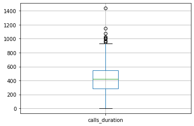

```python
norm_calls_smart.boxplot('calls_duration');
```

Для тарифа Smart существуют аномальные значения, но их количество незначительное, оставляю.

Посчитаю наглядно, сколько нужно сообщений пользователям по каждому тарифу.

```python
print('Пользователям тарифа Ultra в среднем нужно',
      norm_calls_ultra['calls_duration'].median(),
      'из',
      df_tariffs['minutes_included'].loc[1],
      'минут в месяц.')

print('Пользователям тарифа Smart в среднем нужно',
      norm_calls_smart['calls_duration'].median(),
      'из',
      df_tariffs['minutes_included'].loc[0],
      'минут в месяц.')
```

```
Пользователям тарифа Ultra в среднем нужно 529.0 из 3000 минут в месяц.
Пользователям тарифа Smart в среднем нужно 423.0 из 500 минут в месяц.
```

```python
df.query('calls_duration == 0')['last_name'].value_counts().count()
# такое количество пользователей не совершали ни одного звонка в течение месяца хотя бы раз
```

```
271
```

#### Гистограммы

##### Тариф Ultra

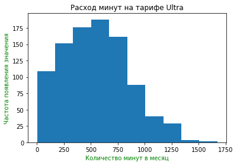

```python
norm_calls_ultra['calls_duration'].plot(kind='hist', title = 'Расход минут на тарифе Ultra')
plt.xlabel('Количество минут в месяц', color='green')
plt.ylabel('Частота появления значения', color='green');
```

##### Тариф Smart

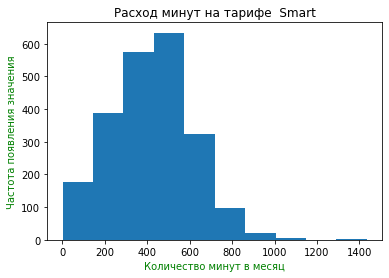

```python
norm_calls_smart['calls_duration'].plot(kind='hist', title = 'Расход минут на тарифе  Smart')
plt.xlabel('Количество минут в месяц', color='green')
plt.ylabel('Частота появления значения', color='green');
```

Гистограмма слегка скошена влево, среднее - 419, а медиана - 423.

#### Дисперсия и стандартное отклонение по звонкам

Нахожу дисперсию и стандартное отклонение по отбоим тарифам и по первоначальному датасету методом var.

```python
print('Дисперсия по тарифу Ultra:', round(np.var(norm_calls_ultra['calls_duration'], ddof = 1)))
print('Стандартное отклонение по тарифу Ultra:', round(np.std(norm_calls_ultra['calls_duration'], ddof = 1)))
print()
print('Дисперсия по тарифу Smart:', round(np.var(norm_calls_smart['calls_duration'], ddof = 1)))
print('Стандартное отклонение по тарифу Smart:', round(np.std(norm_calls_smart['calls_duration'], ddof = 1)))
print()
print('Дисперсия для всего датасета:', round(np.var(df['calls_duration'], ddof = 1)))
print('Стандартное отклонение для всего датасета:', round(np.std(df['calls_duration'], ddof = 1)))
```

```
Дисперсия по тарифу Ultra: 93338
Стандартное отклонение по тарифу Ultra: 306

Дисперсия по тарифу Smart: 35718
Стандартное отклонение по тарифу Smart: 189

Дисперсия для всего датасета: 83519
Стандартное отклонение для всего датасета: 289
```

По правилу трех сигм нахожу правую сторону интервала, в которую попадут все значения по продолжительности звонков.

```python
print('З сигмы для Ultra по звонкам:',
      (norm_calls_ultra['calls_duration'].mean() + 3*np.std(norm_calls_ultra['calls_duration'], ddof = 1)))

print('З сигмы для Smart по звонкам:',
      (norm_calls_smart['calls_duration'].mean() + 3*np.std(norm_calls_smart['calls_duration'], ddof = 1)))
```

```
З сигмы для Ultra по звонкам: 1464.295170236832
З сигмы для Smart по звонкам: 986.417552316999
```

#### Перерасход звонков

```python
a = df.query('extra_minutes >0')['user_id'].count()
b = df.query('extra_minutes >0 and tariff_name=="smart"')['user_id'].count()
c = df.query('extra_minutes >0 and tariff_name=="ultra"')['user_id'].count()
print(f'{a} месяца из {ultra + smart} пользователи не укладывались в тарифы по продолжительности звонков')
print(f'Из которых на тарифе Ultra было {c} месяцев с перерасходом, что составило {c/ultra:.0%} от всех месяцев по тарифу Ultra')
print(f'А на тарифе Smart было {b} месяцев с перерасходом, что составило {b/smart:.0%} от всех месяцев по тарифу Smart')
```

```
754 месяца из 4536 пользователи не укладывались в тарифы по продолжительности звонков
Из которых на тарифе Ultra было 0 месяцев с перерасходом, что составило 0% от всех месяцев по тарифу Ultra
А на тарифе Smart было 754 месяцев с перерасходом, что составило 24% от всех месяцев по тарифу Smart
```

#### Вывод

В среднем пользователям на обоих тарифах необходимо **Ultra** - **529 минуты в месяц**, **Smart** - **423 минуты в месяц**. Эти значения не превышают указанные в тарифах.

Стандартное отклонение для **Ultra - 306 минут**, **для Smart - 189 минут**.  
**31%** записей по тарифу Ultra не содержат ни одной минуты звонка, а в тарифе Smart - **30%**.

У **271** пользователей был хотя бы один месяц в который они не совершили ни одного звонка.

Гистограммы для обоих тарифов выглядят как нормальное распределение.

Дисперсия и стандартное отклонение для тарифа Ultra больше, чем для тарифа Smart:

- Ultra: дисперсия - 93338, стандартное отклонение - 305
- Smart: дисперсия - 35718, стандартное отклонение - 188

По правилу трех сигм нашла правую часть интервала, в который поместятся 99% значений для тарифов:

- для тарифа Ultra верхней границей будет 1464 минуты звонков, это означает, что в 99% случаях пользователи не израсходуют 1538 минут из 3000 минут лимита.
- для тарифа Smart верхней границей будет 986 минут звонков, это означает, что пользователи будут регулярно переплачивать за дополнительные минуты.

Все перерасходы средств по звонкам совершались на тарифе Smart и составили 24% от всех месяцев по тармифу Smart.

### Потребность в сообщениях в месяц

```python
print(df.query('messages == 0')['messages'].count(), 'строк с месяцами без сообщений')

print(df.query('messages == 0 and tariff_name=="ultra"')['messages'].count(),
      'строк с месяцами без сообщений на тарифе Ultra')

print(df.query('messages == 0 and tariff_name=="smart"')['messages'].count(),
      'строк с месяцами без сообщений на тарифе Smart')

print(df.query('messages == 0')['last_name'].value_counts().count(),
      'пользователя хотя бы один месяц не писали ни одного сообщения')
print(f'{251/ ultra:.0%} строк без сообщений на тарифе Ultra')
print(f'{554/smart:.0%} строк без сообщений на тарифе Smart')
```

```
795 строк с месяцами без сообщений
251 строк с месяцами без сообщений на тарифе Ultra
544 строк с месяцами без сообщений на тарифе Smart
184 пользователя хотя бы один месяц не писали ни одного сообщения
18% строк без сообщений на тарифе Ultra
18% строк без сообщений на тарифе Smart
```

Убираю нулевые значения из выборок, чтобы они не мешали, так как интересует поведение тех, кто сообщения писал.

```python
norm_messages_ultra = df.query('tariff_name=="ultra" and messages > 0')
norm_messages_smart = df.query('tariff_name=="smart" and messages > 0')
```

Смотрю среднее, медиану и стандартное отклонение методом describe по очищенным данным для тарифа Ultra.

```python
norm_messages_ultra['messages'].describe()
```

```
count    1130.000000
mean       43.029204
std        46.164435
min         1.000000
25%        12.000000
50%        29.000000
75%        60.000000
max       445.000000
Name: messages, dtype: float64
```

Медиана меньше среднего арифметического, стандартное отклонение 46.  
Строю диаграмму размаха, чтобы посмотреть наличие аномальных значений.

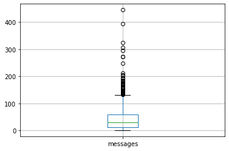

```python
norm_messages_ultra.boxplot('messages');
```

На тарифе Ultra есть много аномальных значений, выходящих за правый(верхний) "ус" диаграммы. Так же как и со звонками, получается, что пользователи тарифа Ultra используют сообщения очень по-разному.

Смотрю среднее, медиану и стандартное отклонение методом describe по очищенным данным для тарифа Smart.

```python
norm_messages_smart['messages'].describe()
```

```
count    2611.000000
mean       28.499809
std        31.470139
min         1.000000
25%         7.000000
50%        18.000000
75%        38.500000
max       268.000000
Name: messages, dtype: float64
```

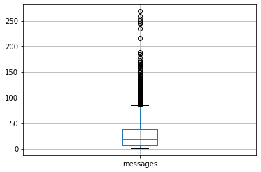

```python
norm_messages_smart.boxplot('messages');
```

На тарифе Smart много аномальных значений, выходящих за правый(верхний) "ус" диаграммы. Пользователям тарифа Smart нужно разное количество сообщений в месяц, многим не хватает тех, что входят в тариф.

Посчитаю наглядно, сколько сообщений нужно пользователям на разных тарифах в месяц.

```python
print('Пользователям тарифа Ultra в среднем нужно',
      norm_messages_ultra['messages'].median(),
      'из',
      df_tariffs['messages_included'].loc[1],
      'сообщений в месяц.')
print('Пользователям тарифа Smart в среднем нужно',
      norm_messages_smart['messages'].median(),
      'из',
      df_tariffs['messages_included'].loc[0],
      'сообщений в месяц.')
```

```
Пользователям тарифа Ultra в среднем нужно 29.0 из 1000 сообщений в месяц.
Пользователям тарифа Smart в среднем нужно 18.0 из 50 сообщений в месяц.
```

#### Гистограммы

##### Тариф Ultra

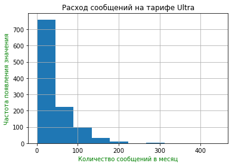

```python
norm_messages_ultra['messages'].plot(kind='hist', title = 'Расход сообщений на тарифе Ultra', grid = True)
plt.xlabel('Количество сообщений в месяц', color='green')
plt.ylabel('Частота появления значения', color='green');
```

Медиана меньше среднего, график скошен вправо.

##### Тариф Smart

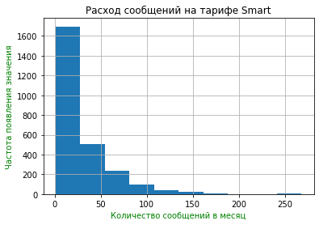

```python
norm_messages_smart['messages'].plot(kind='hist', title = 'Расход сообщений на тарифе Smart', grid = True)
plt.xlabel('Количество сообщений в месяц', color='green')
plt.ylabel('Частота появления значения', color='green');
```

Медиана меньше среднего, график скошен вправо.

#### Дисперсия и стандартное отклонение по сообщениям

Нахожу дисперсию и стандартное отклонение по отбоим тарифам и по первоначальному датасету методом var.

```python
print('Дисперсия по тарифу Ultra:', round(np.var(norm_messages_ultra['messages'], ddof = 1)))
print('Стандартное отклонение по тарифу Ultra:', round(np.std(norm_messages_ultra['messages'], ddof = 1)))
print()
print('Дисперсия по тарифу Smart:', round(np.var(norm_messages_smart['messages'], ddof = 1)))
print('Стандартное отклонение по тарифу Smart:', round(np.std(norm_messages_smart['messages'], ddof = 1)))
print()
print('Дисперсия для всего датасета:', round(np.var(df['messages'], ddof = 1)))
print('Стандартное отклонение для всего датасета:', round(np.std(df['messages'], ddof = 1)))
```

```
Дисперсия по тарифу Ultra: 2131
Стандартное отклонение по тарифу Ultra: 46

Дисперсия по тарифу Smart: 990
Стандартное отклонение по тарифу Smart: 31

Дисперсия для всего датасета: 1294
Стандартное отклонение для всего датасета: 36
```

По правилу трех сигм ищу верхнюю границу по расходу сообщений.

```python
print('З сигмы для Ultra по сообщениям:',
      (norm_messages_ultra['messages'].mean() + 3*np.std(norm_messages_ultra['messages'], ddof = 1)))

print('З сигмы для Smart по сообщениям:',
      (norm_messages_smart['messages'].mean() + 3*np.std(norm_messages_smart['messages'], ddof = 1)))
```

```
З сигмы для Ultra по сообщениям: 181.52250781513925
З сигмы для Smart по сообщениям: 122.91022489712113
```

#### Перерасход сообщений

```python
a = df.query('extra_messages >0')['user_id'].count()
b = df.query('extra_messages >0 and tariff_name=="smart"')['user_id'].count()
c = df.query('extra_messages >0 and tariff_name=="ultra"')['user_id'].count()
print(f'{a} месяца из {ultra + smart} пользователи не укладывались в тарифы по количеству сообщений.')
print(f'Из которых на тарифе Ultra было {c} месяцев с перерасходом, что составило {c/ultra:.0%} от всех месяцев по тарифу Ultra')
print(f'А на тарифе Smart было {b} месяцев с перерасходом, что составило {b/smart:.0%} от всех месяцев по тарифу Smart')
```

```
464 месяца из 4536 пользователи не укладывались в тарифы по количеству сообщений.
Из которых на тарифе Ultra было 0 месяцев с перерасходом, что составило 0% от всех месяцев по тарифу Ultra
А на тарифе Smart было 464 месяцев с перерасходом, что составило 15% от всех месяцев по тарифу Smart
```

#### Вывод

В среднем пользователям на обоих тарифах необходимо на тарифе Ultra - 29 сообщений, на тарифе Smart - 18 сообщений. Эти значения не превышают указанные в тарифах.

На обоих тарифах по 18% строк содержат информацию о том, что пользовтель не отправил ни одного сообщения за месяц.  
184 пользователя хотя бы один месяц не писали ни одного сообщения.

Пользователи ведут себя примерно одинаково, гистограммы и диаграммы размаха похожи.  
Для обоих тарифах много значений выходят за крайнюю границу диаграммы размаха. Это значит, что многие пользователи пишут гораздо больше сообщений, чем обычный пользователь.

Дисперсия и стандартное отклонение по тарифу Ultra больше, чем по тарифу Smart:

- Ultra: дисперсия - 2131, стандартное отклонение - 46.
- Smart: дисперсия - 990, стандартное отклонение - 31.

Воспользовавшись правилом трех сигм, установила, что:

- для тарифа Ultra в 99% случаев пользователи не отправят в месяц более 181 сообщения, таким образом переплатив за 819 сообщений из 1000,
- для тарифа Smart в 99% случаев пользователи не отправят в месяц более 122 сообщений, тем самым переплатив за сообщения, превышиющие лимит в 50 сообщений.

Перерасход сообщений был только на тарифе Smart и составил 15%.

### Потребность в интернет-трафике в месяц

```python
print(df.query('mb_used == 0')['messages'].count(), 'строк с месяцами без использования интернета')

print(df.query('mb_used == 0 and tariff_name=="ultra"')['messages'].count(),
      'строк с месяцами без интернета на тарифе Ultra')

print(df.query('mb_used == 0 and tariff_name=="smart"')['messages'].count(),
      'строк с месяцами без интернета на тарифе Smart')

print(df.query('mb_used == 0')['last_name'].value_counts().count(),
      'пользователя хотя бы один месяц не использовали интернет')
print(f'{407/ultra:.0%} строк с нулевым использованием интернета на тарифе Ultra')
print(f'{928/smart:.0%} строк с нулевым использованием интернета на тарифе Smart')
```

```
1335 строк с месяцами без использования интернета
407 строк с месяцами без интернета на тарифе Ultra
928 строк с месяцами без интернета на тарифе Smart
268 пользователя хотя бы один месяц не использовали интернет
29% строк с нулевым использованием интернета на тарифе Ultra
29% строк с нулевым использованием интернета на тарифе Smart
```

Убираю строки с нулевыми значениями, так как интересны те, кто интернетом пользовались.

```python
norm_traffic_ultra = df.query('tariff_name=="ultra" and mb_used >0')
norm_traffic_smart = df.query('tariff_name=="smart" and mb_used >0')
```

Считаю медиану, среднее и стандартное отклонение методом np.var() для тарифа **Ultra**.

```python
print('Медиана:', norm_traffic_ultra['mb_used'].median())
print('Среднее арифметическое:', norm_traffic_ultra['mb_used'].mean())
print('Стандартное отклонение:',np.std(norm_traffic_ultra['mb_used'], ddof = 1))
```

```
Медиана: 19409.025
Среднее арифметическое: 19688.678778234094
Стандартное отклонение: 9928.134987416308
```

Медианное значение близко к среднему.  
Строю диаграмму размаха, чтобы посмотреть аномальные значения.

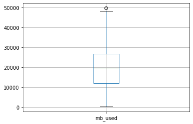

```python
norm_traffic_ultra.boxplot('mb_used');
```

Практически не осталось аномальных значений.

Считаю медиану, среднее и стандартное отклонение методом np.var() для тарифа **Smart**.

```python
print('Медиана:', norm_traffic_smart['mb_used'].median())
print('Среднее арифметическое:', norm_traffic_smart['mb_used'].mean())
print('Стандартное отклонение:',np.std(norm_traffic_smart['mb_used'], ddof = 1))
```

```
Медиана: 16508.64
Среднее арифметическое: 16222.943242029643
Стандартное отклонение: 5852.96580638762
```

Для тарифа Smart медианное значение близко к среднему, как и для тарифа Ultra.  
Строю диаграмму размаха.

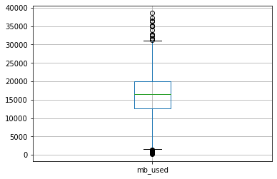

```python
norm_traffic_smart.boxplot('mb_used');
```

Для тарифа Smart аномальные значения есть как с левой (нижней), так и с правой(верхней) стороны графика.

#### Гистограммы

##### Тариф Ultra

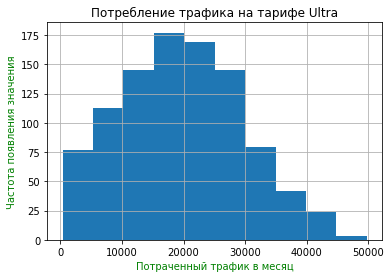

```python
norm_traffic_ultra['mb_used'].plot(kind='hist', title = 'Потребление трафика на тарифе Ultra', grid = True);
plt.xlabel('Потраченный трафик в месяц', color='green')
plt.ylabel('Частота появления значения', color='green');
```

##### Тариф Smart

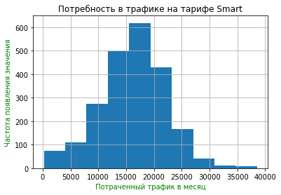

```python
norm_traffic_smart['mb_used'].plot(kind='hist', title = 'Потребность в трафике на тарифе Smart', grid = True);
plt.xlabel('Потраченный трафик в месяц', color='green')
plt.ylabel('Частота появления значения', color='green');
```

Для тарифа Smart распределение нормальное с небольшой скошенностью влево.

```python
print('Пользователям тарифа Ultra в среднем нужно',
      norm_traffic_ultra['mb_used'].median(),
      'МБ из',
      df_tariffs['mb_per_month_included'].loc[1],
      'МБ в месяц.')
print('Пользователям тарифа Smart в среднем нужно',
      norm_traffic_smart['mb_used'].median(),
      'МБ из',
      df_tariffs['mb_per_month_included'].loc[0],
      'МБ в месяц.')
```

```
Пользователям тарифа Ultra в среднем нужно 19409.025 МБ из 30720 МБ в месяц.
Пользователям тарифа Smart в среднем нужно 16508.64 МБ из 15360 МБ в месяц.
```

#### Дисперсия для интернет-трафика

Считаю дисперсию для интернет-трафика по тарифам.

```python
print('Дисперсия по тарифу Ultra:', np.var(norm_traffic_ultra['mb_used'], ddof = 1))
print('Стандартное отклонение по тарифу Ultra:', np.std(norm_traffic_ultra['mb_used'], ddof = 1))
print()
print('Дисперсия по тарифу Smart:', np.var(norm_traffic_smart['mb_used'], ddof = 1))
print('Стандартное отклонение по тарифу Smart:', np.std(norm_traffic_smart['mb_used'], ddof = 1))
```

```
Дисперсия по тарифу Ultra: 98567864.32835983
Стандартное отклонение по тарифу Ultra: 9928.134987416308

Дисперсия по тарифу Smart: 34257208.730742685
Стандартное отклонение по тарифу Smart: 5852.96580638762
```

Воспользовавшись правилом трех сигм ищу верхнюю границу для большинства пользователей по использованию интернета.

```python
print('З сигмы для Ultra по интернет-трафику:',
      (norm_traffic_ultra['mb_used'].mean() + 3*np.std(norm_traffic_ultra['mb_used'], ddof = 1)))
print('З сигмы для Smart по интернет-трафику:',
      (norm_traffic_smart['mb_used'].mean() + 3*np.std(norm_traffic_smart['mb_used'], ddof = 1)))
```

```
З сигмы для Ultra по интернет-трафику: 49473.08374048302
З сигмы для Smart по интернет-трафику: 33781.8406611925
```

#### Перерасход трафика

```python
a = df.query('extra_traffic >0')['user_id'].count()
b = df.query('extra_traffic >0 and tariff_name=="smart"')['user_id'].count()
c = df.query('extra_traffic >0 and tariff_name=="ultra"')['user_id'].count()
print(f'{a} месяца из {ultra + smart} пользователи не укладывались в тарифы по объему израсходованного интернета.')
print(f'Из которых на тарифе Ultra было {c} месяцев с перерасходом, что составило {c/ultra:.0%} от всех месяцев по тарифу Ultra')
print(f'А на тарифе Smart было {b} месяцев с перерасходом, что составило {b/smart:.0%} от всех месяцев по тарифу Smart')
```

```
1438 месяца из 4536 пользователи не укладывались в тарифы по объему израсходованного интернета.
Из которых на тарифе Ultra было 134 месяцев с перерасходом, что составило 10% от всех месяцев по тарифу Ultra
А на тарифе Smart было 1304 месяцев с перерасходом, что составило 41% от всех месяцев по тарифу Smart
```

#### Вывод

Для пользователей тарифа Ultra в среднем достаточно **19409 МБ** из **30720 МБ** в месяц.  
Для пользователей Smart - **16508 МБ** из **15360 МБ**. Среднее по тарифу Smart не укладывается в лимит.

268 пользователей хотя бы один месяц не пользовались интернетом.  
29% строк для обоих тарифов содержат информации о том, что пользователь ни разу за месяц не воспользовался интернетом.

Гистограммы для обоих тарифов выглядят как нормальное распределение.  
На диаграмме размаха видно, что по тарифу Smart больше аномальных значений, чем по тарифу Ultra.

Дисперсия и стандартное отклонение по тарифу Ultra больше, чем по тарифу Smart:

- Ultra: дисперсия 98567864, стандартное отклонение 9928
- Smart: дисперсия 34257208, стандартное отклонение 5852

Рассчитав по правилу трех сигм по обоим тарифам верхний предел использования интернет-трафика для 99% значений, выяснила, что пользователи и тарифа Ultra, и тарифа Smart будут регулярно переплачивать за интернет.

По обоим тарифам был перерасход интернет-трафика, 10% месяцев пользователи выходили за лимит по тарифу Ultra и 41% месяцев по тарифу Smart.

### Дисперсия, стандартное отклонение и гистограммы по выручке

```python
ultra_total_cost = df.query('tariff_name=="ultra"')['total_cost']
smart_total_cost = df.query('tariff_name=="smart"')['total_cost']

print('Дисперсия по тарифу Ultra:', np.var(ultra_total_cost, ddof = 1))
print('Стандартное отклонение по тарифу Ultra:', np.std(ultra_total_cost, ddof = 1))
print()
print('Дисперсия по тарифу Smart:', np.var(smart_total_cost, ddof = 1))
print('Стандартное отклонение по тарифу Smart:', np.std(smart_total_cost, ddof = 1))
```

```
Дисперсия по тарифу Ultra: 103862.35557094947
Стандартное отклонение по тарифу Ultra: 322.2768306455639

Дисперсия по тарифу Smart: 584257.2338462953
Стандартное отклонение по тарифу Smart: 764.3672113888032
```

У пользователей Ultra стандартное отклонение меньше в 2 раза, чем по тарифу Smart, это означает, что пользователи Ultra в большинстве своем платят одну и ту же сумму, в то время как пользователи Smart платят разную сумму за услуги. Так как заплатить меньше абонентской платы нельзя, то платят они больше.  
Строю гистограммы по тарифам.

```python
df_tariffs
```

|  | messages_included | mb_per_month_included | minutes_included | rub_monthly_fee | rub_per_gb | rub_per_message | rub_per_minute | tariff_name |
| --- | --- | --- | --- | --- | --- | --- | --- | --- |
| 0 | 50 | 15360 | 500 | 550 | 200 | 3 | 3 | smart |
| 1 | 1000 | 30720 | 3000 | 1950 | 150 | 1 | 1 | ultra |

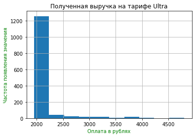

```python
ultra_total_cost.plot(kind='hist', title = 'Полученная выручка на тарифе Ultra', grid = True);
plt.xlabel('Оплата в рублях', color='green')
plt.ylabel('Частота появления значения', color='green');
```

Из графика видно, что пользователи тарифа Ultra не так часто и не так много переплачивают за услуги сверх лимитов сверх абонентской платы в 1950 рублей.

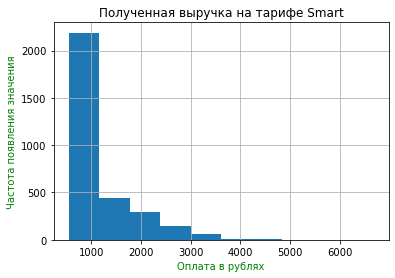

```python
smart_total_cost.plot(kind='hist', title = 'Полученная выручка на тарифе Smart', grid = True);
plt.xlabel('Оплата в рублях', color='green')
plt.ylabel('Частота появления значения', color='green');
```

Из графика видно, что пользователи часто переплачивают сверх 550 рублей абонентской платы в несколько раз.

### Вывод по анализу данных

По продолжительности телефонных звонков и количеству сообщений происходит перерасход по тарифу Smart, пользователи тарифа Ultra не выходят за лимит тарифа по этим показателям. По интернет-трафику пользователи обоих тарифов выходят за установленные лимиты, тем не менее, пользователи тарифа Smart выходят за пределы установленного лимита чаще.

По всем трем параметрам в обоих тарифах большое стандартное отклонение, что говорит о том, что данные неоднородны, множество пользователей используют больший или меньший объем звонков, сообщений и трафика в месяц.

Для обоих тарифов было бы хорошо поднять лимит по интернет-трафику или создать еще один тариф, средний между Smart и Ultra по звонкам и сообщениям, но с большим лимитом интернет-трафика.

Дисперсия и стандартное отклонение по выручке по тарифу Ultra меньше, чем по тарифу Smart. Значит тариф Ultra больше подходит своим пользователям, их траты более стабильные от месяца к месяцу.

## Проверка гипотез

Нужно проверить две гипотезы:

- средняя выручка пользователей тарифов «Ультра» и «Смарт» различаются;
- средняя выручка пользователей из Москвы отличается от выручки пользователей из других регионов.

```python
df.head()
```

|  | user_id | month | calls_count | calls_duration | messages | mb_used | age | churn_date | city | first_name | last_name | reg_date | tariff | messages_included | mb_per_month_included | minutes_included | rub_monthly_fee | rub_per_gb | rub_per_message | rub_per_minute | tariff_name | extra_minutes | extra_messages | extra_traffic | total_cost |
| --- | --- | --- | --- | --- | --- | --- | --- | --- | --- | --- | --- | --- | --- | --- | --- | --- | --- | --- | --- | --- | --- | --- | --- | --- | --- |
| 0 | 1000 | 2018-05-01 | 22 | 159 | 22 | 2253.49 | 52 | NaN | Краснодар | Рафаил | Верещагин | 2018-05-25 | ultra | 1000 | 30720 | 3000 | 1950 | 150 | 1 | 1 | ultra | 0 | 0 | 0.0 | 1950.0 |
| 1 | 1000 | 2018-06-01 | 43 | 172 | 43 | 23233.77 | 52 | NaN | Краснодар | Рафаил | Верещагин | 2018-05-25 | ultra | 1000 | 30720 | 3000 | 1950 | 150 | 1 | 1 | ultra | 0 | 0 | 0.0 | 1950.0 |
| 2 | 1000 | 2018-07-01 | 47 | 340 | 47 | 14003.64 | 52 | NaN | Краснодар | Рафаил | Верещагин | 2018-05-25 | ultra | 1000 | 30720 | 3000 | 1950 | 150 | 1 | 1 | ultra | 0 | 0 | 0.0 | 1950.0 |
| 3 | 1000 | 2018-08-01 | 52 | 408 | 53 | 14055.93 | 52 | NaN | Краснодар | Рафаил | Верещагин | 2018-05-25 | ultra | 1000 | 30720 | 3000 | 1950 | 150 | 1 | 1 | ultra | 0 | 0 | 0.0 | 1950.0 |
| 4 | 1000 | 2018-09-01 | 58 | 466 | 59 | 14568.91 | 52 | NaN | Краснодар | Рафаил | Верещагин | 2018-05-25 | ultra | 1000 | 30720 | 3000 | 1950 | 150 | 1 | 1 | ultra | 0 | 0 | 0.0 | 1950.0 |

### Проверка гипотезы "средняя выручка пользователей тарифов «Ультра» и «Смарт» различаются"

Нулевая гипотеза: Средняя выручка пользователей тарифов Ultra и Smart равна.  
Альтернативная гипотеза: Средняя выручка пользователей тарифов Ultra и Smart не равна.

Гипотеза является двусторонней, так как выручка может быть как больше, так и меньше. Проверить гипотезу можно с помощью t-теста для гипотезы о равенстве двух генеральных совокупностей.  
Первая совокупность - это все данные о выручке по тарифу Ultra.  
Вторая совокупность - это все данные о выручке по тарифу Smart.

```python
ultra_total_cost = df.query('tariff_name=="ultra"')['total_cost']
smart_total_cost = df.query('tariff_name=="smart"')['total_cost']

results = st.ttest_ind(ultra_total_cost,smart_total_cost)
alpha = 0.05
print('p-значение: ', results.pvalue)

if results.pvalue < alpha:
    print("Отвергаем нулевую гипотезу")
else:
    print("Не получилось отвергнуть нулевую гипотезу")
```

```
p-значение:  0.0
Отвергаем нулевую гипотезу
```

Гипотеза о том, что средняя выручка пользователей тарифов равна отвергнута.  
Считаем верной альтернативную гипотезу, что средняя выручка на тарифах Ultra и Smart не равна.

Меня очень смущает p-значение: 0.0, смотрю среднюю выручку по тарифам в выборках.

```python
ultra_total_cost.mean()
```

```
2035.6987690079652
```

```python
smart_total_cost.mean()
```

```
1074.9194928684628
```

Средняя выручка не равна.

### Проверка гипотезы "средняя выручка пользователей из Москвы отличается от выручки пользователей из других регионов"

Нулевая гипотеза: Средняя выручка пользователей из Москвы и других регионов равна.  
Альтернативная гипотеза: Средняя выручка пользователей из Москвы и других регионов не равна.

Гипотеза является двусторонней, так как выручка может быть как больше, так и меньше. Проверить гипотезу можно с помощью t-теста для гипотезы о равенстве двух генеральных совокупностей.  
Первая совокупность - это все данные о выручке по Москве.  
Вторая совокупность - это все данные о выручке всем регионам кроме Москвы.

```python
moscow_total_cost = df.query('city=="Москва"')['total_cost']
other_total_cost = df.query('city!="Москва"')['total_cost']

results = st.ttest_ind(moscow_total_cost,other_total_cost)
alpha = 0.05
print('p-значение: ', results.pvalue)

if results.pvalue < alpha:
    print("Отвергаем нулевую гипотезу")
else:
    print("Не получилось отвергнуть нулевую гипотезу")
```

```
p-значение:  0.7653675827660593
Не получилось отвергнуть нулевую гипотезу
```

Гипотезу о том, что средняя выручка пользователей из Москвы равна средней выручке пользователей из других регионов, не получилось отвергнуть.  
Считаю среднюю выручку по Москве и другим регионам в выборках.

```python
moscow_total_cost.mean()
```

```
1360.2269099201824
```

```python
other_total_cost.mean()
```

```
1369.1587865537033
```

Средняя выручка практически равна.

## Вывод

Пользователи тарифа **Smart** чаще выходят за лимит по своему тарифу, чем пользователи тарифа Ultra. 24 % - не хватает звонков на тарифе **Smart**. 15% не хватает сообщений на тарифе **Smart**. 41% не хватает интернет-трафика на тарифе **Smart**. 10% - не хватает интернета на тарифе **Ultra**.

**Выручка по тарифу Ultra больше, чем по тарифу Smart.**

Мне необходимо сделать вывод, какой тариф лучше.

С точки зрения пользователя оба тарифа не очень удобные, так как пользователь Ultra сразу переплачивает за услуги, которыми не пользуется, а пользователь тарифа Smart постоянно переплачивает за услуги, которые не входят в лимиты по тарифу.

С точки зрения компании «Мегалайн» в краткосрочной перспективе тариф Ultra лушче, он приносит больше денег.  
Но как только у конкурентов появится тариф с лимитами:  
1500 минут, 200 сообщений и 50 гигабайт интернета за сумму, меньшую, чем абонентская плата по тарифу Ultra,  
пользователи могут покинуть оператора.

Конкурентным преимуществом является достаточное количество интернета, так как пользователи обоих тарифов испытывают нехватку установленного тарифами лимита.